# Activity Data Analysis

Nitish Dobhal

July 21, 2017

## Introduction

This data is a part of the research in the “Quantified Self” movement, in which the individuals through use of modern devices can track their personal activities as well as health. This data is then processed and analyzed to better the health of the individual.

The given data was collected for a duration of 2 months and recorded activity i.e steps taken every 5 minute. This work aims to get the basic statistics in form of mean and medians of data, as well a comparison of activities during weekdays and weekends.

## Loading Data

The data is loaded from the [link](https://d396qusza40orc.cloudfront.net/repdata%2Fdata%2Factivity.zip) provided within the assignment page. The following code makes sure that the data files are not downloaded unless they are not found in the working directory.

```r
fname<-"ActivityData.zip"
if(!file.exists(fname)) {
  url<-"https://d396qusza40orc.cloudfront.net/repdata%2Fdata%2Factivity.zip"
  download.file(url, destfile = "ActivityData.zip")
}
unzip("ActivityData.zip")
a_data<-read.csv("activity.csv")
```

## Transforming Data

```r
a_data<-a_data[!is.na(a_data$steps),]
a_data<-droplevels(a_data)
```

## Calculating Basic Statistics (without Imputation)

### a)Total Steps each day

For calculating the total number of steps, we will apply the tapply function on the ‘steps’ vector with factor variable ‘date’ and use sum function.

```r
t_steps<-tapply(a_data$steps,a_data$date,sum,simplify = T)
summary(t_steps)
```

```
##    Min. 1st Qu.  Median    Mean 3rd Qu.    Max.
##      41    8841   10760   10770   13290   21190
```

### b)Histogram of Total Steps per day

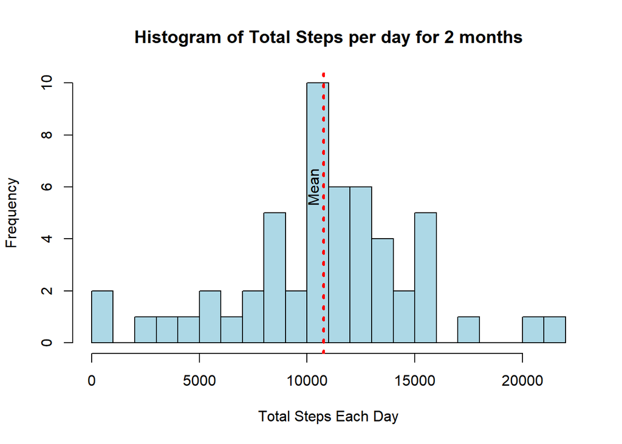

```r
mean_total<-mean(t_steps)
names(mean_total)<-"Mean"
med_total<-median(t_steps)
names(med_total)<-"Median"
hist(t_steps,breaks=20,xlab = "Total Steps Each Day",main="Histogram of Total Steps per day for 2 months",col="lightblue")
abline(v=mean_total,lty=3,lwd=3,col="red")
text(mean_total-500,6,"Mean",srt=90)
```

### c)Mean & Median of the total steps taken each day

```r
mean_total
```

```
##     Mean
## 10766.19
```

```r
med_total
```

```
## Median
##  10765
```

### d)Average daily activity pattern

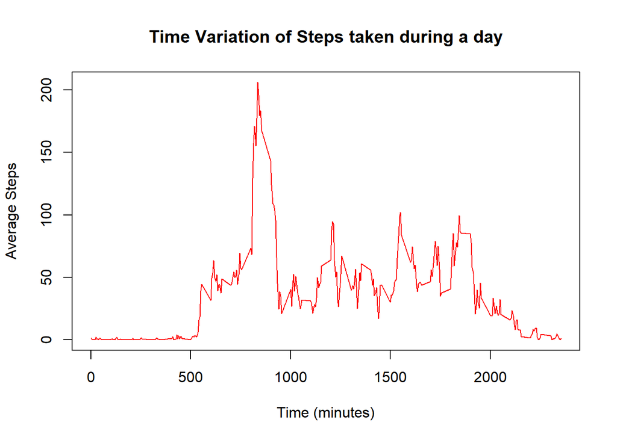

```r
time_steps<-as.data.frame(tapply(a_data$steps,a_data$interval,mean,simplify = T))
names(time_steps)<-"steps"
time_steps$interval<-as.numeric(row.names(time_steps))
row.names(time_steps)<-NULL
plot(y=time_steps$steps,x=time_steps$interval,type="l",xlab = "Time (minutes)",ylab="Average Steps",main = "Time Variation of Steps taken during a day",col="red")
```

### e)Finding 5-minute interval with most steps on an average

```r
max_step_i<-names(which(time_steps$steps==max(time_steps$steps)))
max_step_i
```

```
## [1] "835"
```

## Calculating Basic Statistics (with Imputation)

A simple imputation using the **mean** of steps taken for a particular interval is done. All the missing rows are first extracted into a separate data frame. ‘match’ function is used to lookup the ‘interval’ for a particular row in the ‘time_steps’ variable (used earlier to store average steps for each interval) and corrosponding value of ‘steps’ is returned. This is repeated over all the rows using ‘sapply’ function. The rows with imputed data is then merged back with the original data

```r
a_data2<-read.csv("activity.csv")
missing_V<-a_data2[is.na(a_data2$steps),]
pctage_m<-mean(is.na(a_data2$steps))
missing_V$steps<-sapply(missing_V$interval,function(x)time_steps$steps[match(x,time_steps$interval)])
a_data2[is.na(a_data2$steps),]<-missing_V
```

The original percentage of missing values is shown below. The new imputed data is stored in ‘a_data2’.

```r
paste0(as.character(round(pctage_m,4)*100),"%")
```

```
## [1] "13.11%"
```

### a)Histogram of Total Steps per day with imputation

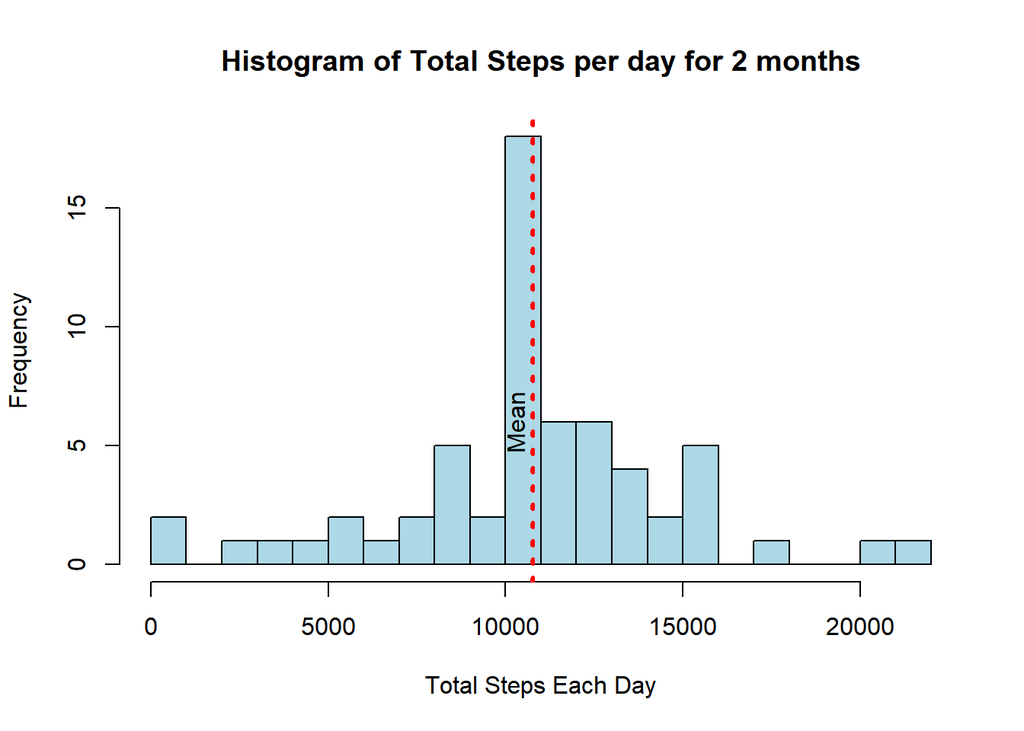

```
## [1] "Original Mean without Imputation: 10766.19"
```

```
## [1] "New Mean with Imputation: 10766.19"
```

```
## [1] "Original Median without Imputation: 10765"
```

```
## [1] "New Median with Imputation: 10766.19"
```

```r
t_steps2<-tapply(a_data2$steps,a_data2$date,sum,simplify = T)
mean_total2<-mean(t_steps2)
names(mean_total2)<-"Mean"
med_total2<-median(t_steps2)
names(med_total2)<-"Median"

hist(t_steps2,breaks=20,xlab = "Total Steps Each Day",main="Histogram of Total Steps per day for 2 months",col="lightblue")
abline(v=mean_total2,lty=3,lwd=3,col="red")
text(mean_total2-500,6,"Mean",srt=90)
```

There is no difference in the new and old mean because the imputed values are derived from the original mean value. The median has increased as there are more values weighted towards the mean value than before.

## Difference in activity between Weekdays & Weekends

To find out if a given date is a weekday or weekend, ‘weekdays()’ function has been used. Since this function accepts an argument of ‘Date’ type, the ‘date’ vector of ‘a_data2’ is first coerced into a date object. Consequently a new logical vector ‘weekd’ is added indicating if a given day is weekend(True) or not(False). ‘tapply’ function is then applied on both groups separately to extract the time series data into two separate variables- ‘time_steps_we’ & ‘time_steps_wd’.

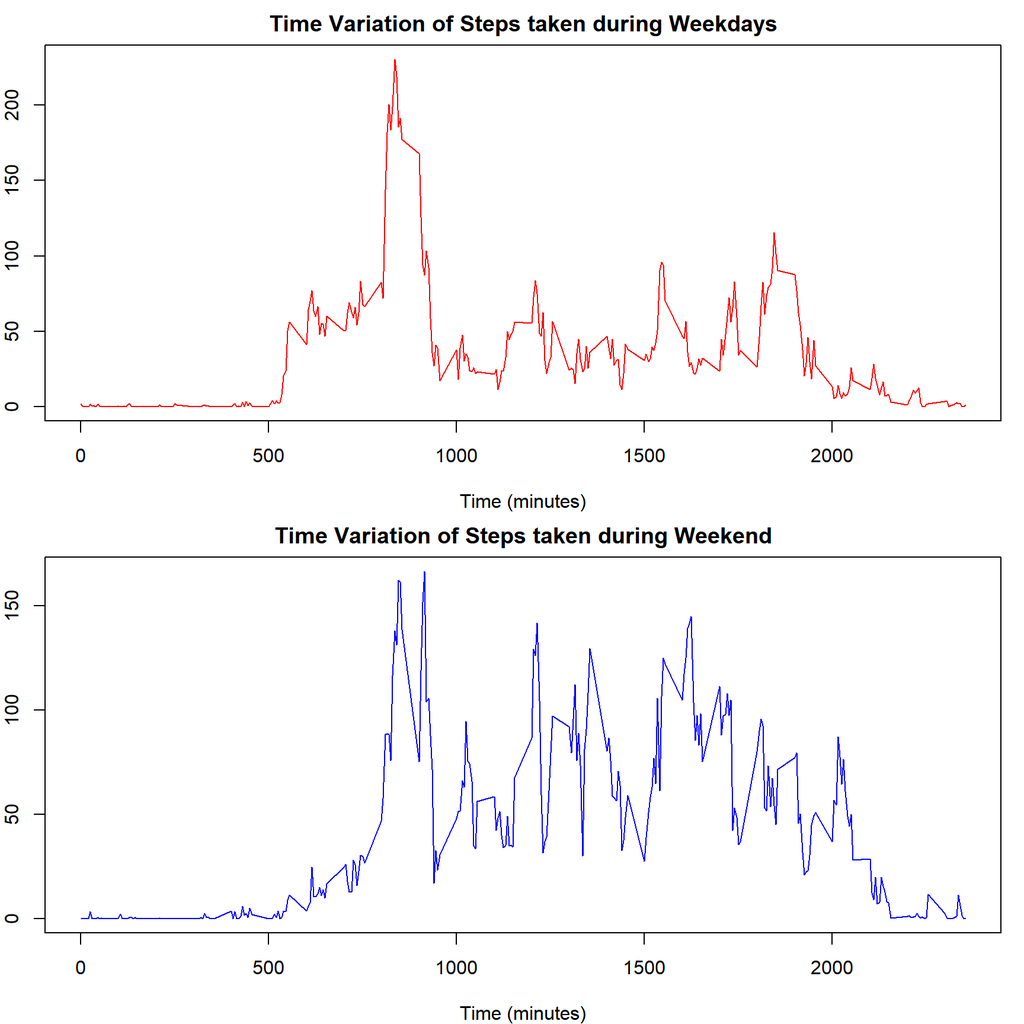

```r
a_data2$date<-as.Date(a_data2$date,"%Y-%m-%d")
a_data2$weekd<-grepl("S.+",weekdays(a_data2$date))
time_steps_we<-as.data.frame(tapply(a_data2[a_data2$weekd,1],a_data2[a_data2$weekd,3],mean,simplify = T))
time_steps_wd<-as.data.frame(tapply(a_data2[!a_data2$weekd,1],a_data2[!a_data2$weekd,3],mean,simplify = T))
names(time_steps_we)<-"steps"
names(time_steps_wd)<-"steps"
time_steps_we$interval<-as.numeric(row.names(time_steps_we))
time_steps_wd$interval<-as.numeric(row.names(time_steps_wd))
par(mfrow=c(2,1),mar=c(4,2,2,1))
plot(time_steps_wd$steps,x=time_steps_wd$interval,type="l",xlab= "Time (minutes)",ylab="Average Steps",main = "Time Variation of Steps taken during Weekdays",col="red")
plot(time_steps_we$steps,x=time_steps_we$interval,type="l",xlab= "Time (minutes)",ylab="Average Steps",main = "Time Variation of Steps taken during Weekend",col="blue")
```